# LiveSessionAssignment11

Ruby Vazquez Pena

11/27/2016

1. Go through the electric equipment example.

```r
library("fpp") #fpp package must be installed first
```

1. Plot the time series. Can you identify seasonal fluctuations and/or a trend?

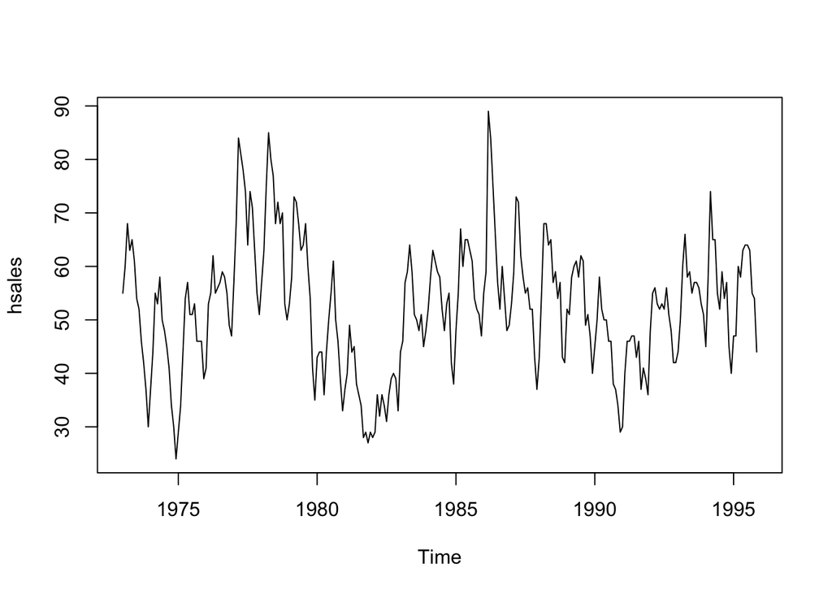

```r
data(hsales)
plot(hsales)
```

We see that every 5 years we decrease, then the next 5 years we increase.

2. Use a classical decomposition to calculate the trend-cycle and seasonal indices.

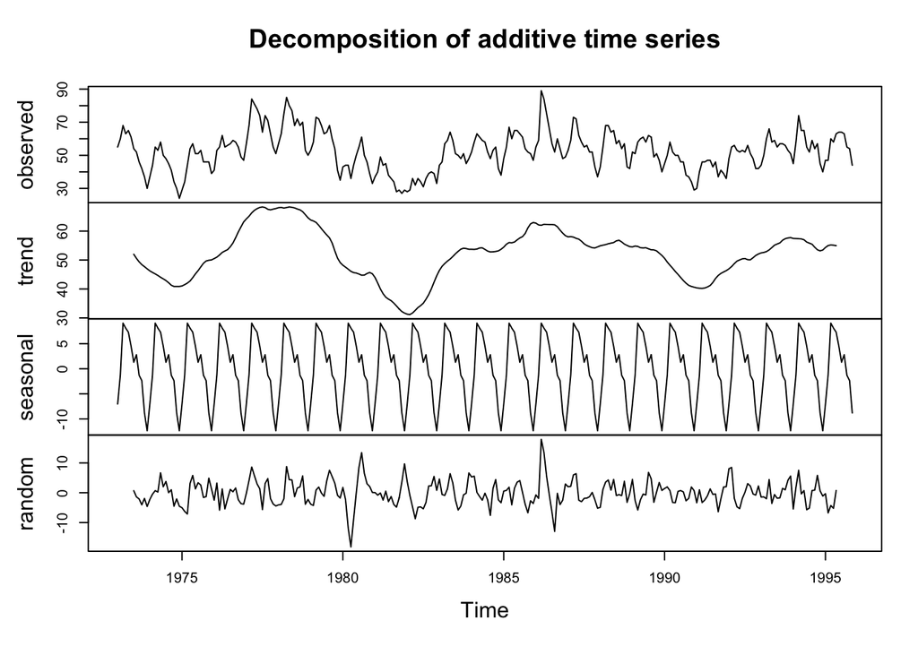

```r
fitd <- decompose(hsales)
plot(fitd)
```

3. Do the results support the graphical interpretation from part (a)? Yes the trend graph suppots the graphical interpretation from part a, the alternation every 5 years.
4. Compute and plot the seasonally adjusted data.

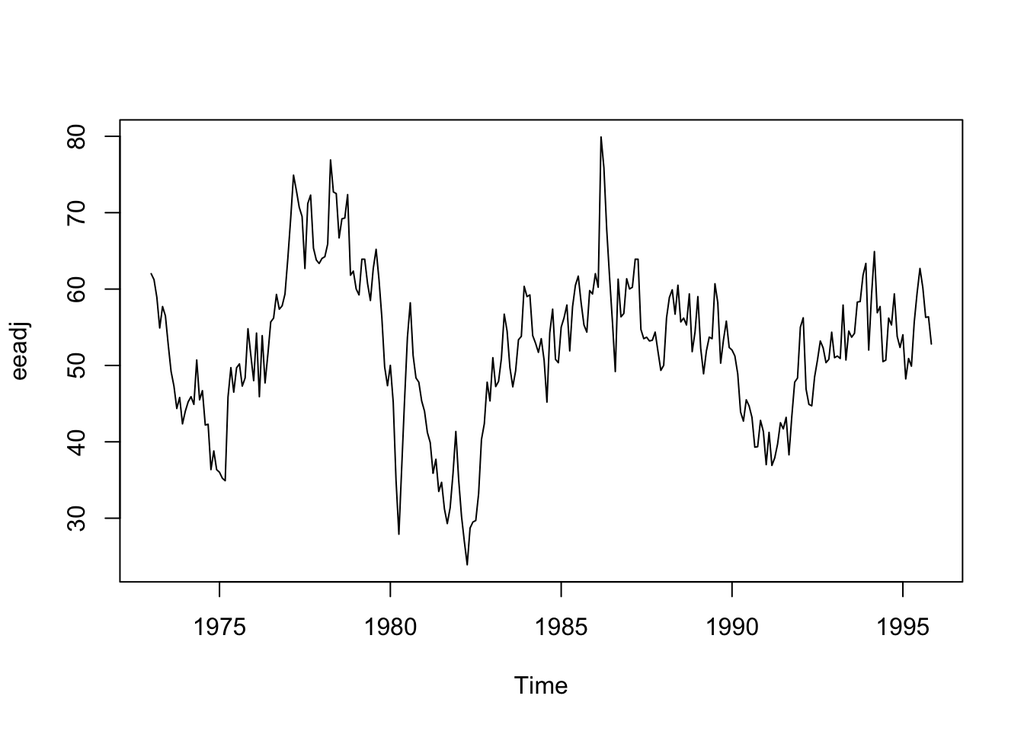

```r
eeadj <- seasadj(fitd)
plot(eeadj)
```

5. Change one observation to be an outlier (e.g., add 500 to one observation), and recompute the seasonally adjusted data. What is the effect of the outlier?

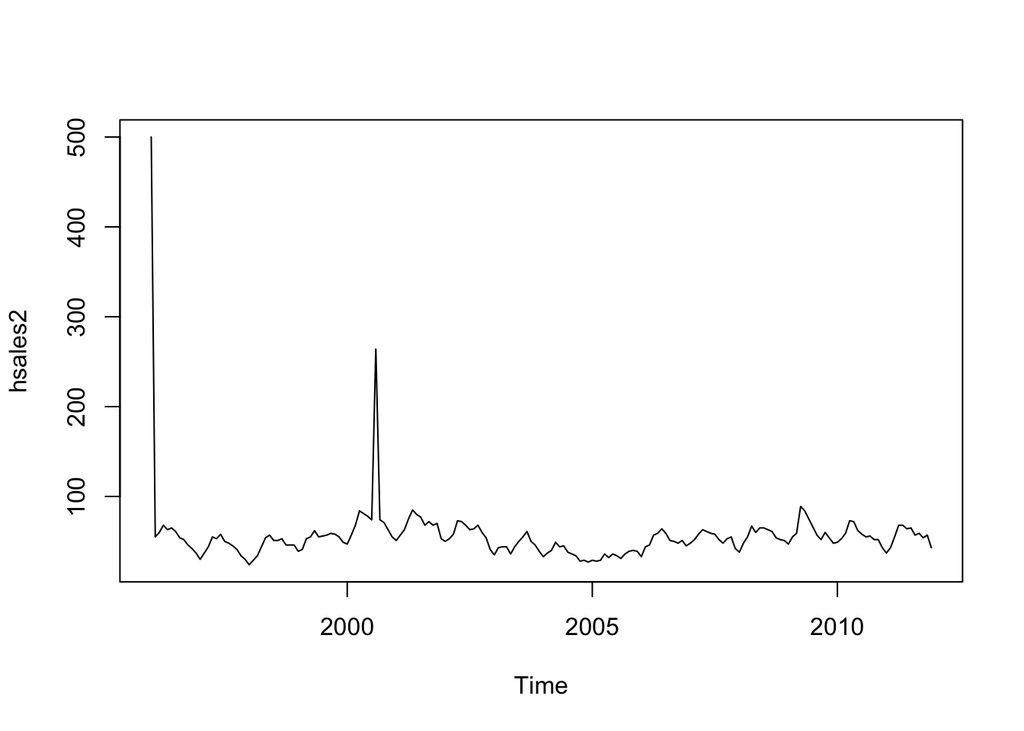

```r
hsales2 <- ts(c(500,hsales[1:54],hsales[55]+200,hsales[56:191]),start=c(1996,1),frequency=12)
plot(hsales2)
```

We have a peak in the location of the outlier.

7. Use STL to decompose the series.

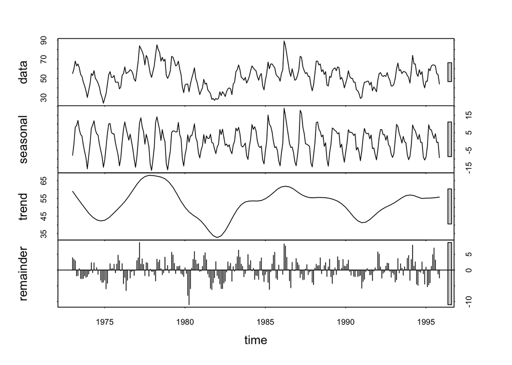

```r
fit <- stl(hsales, s.window=5)
plot(fit)
```

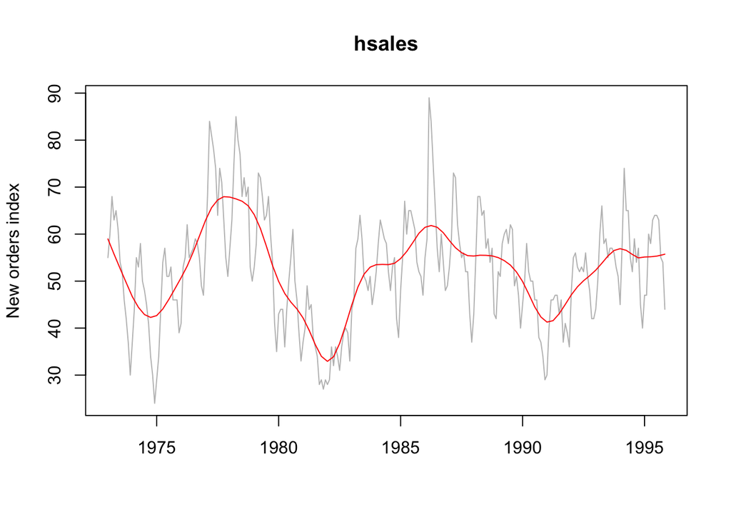

```r
plot(hsales, col="gray",
     main="hsales",
     ylab="New orders index", xlab="")
lines(fit$time.series[,2],col="red",ylab="Trend")
```

6. Does it make any difference if the outlier is near the end rather than in the middle of the time series? There is no difference having the outlier near the end or in the middle of the time series. It makes a difference having the outlier in the front.